# Custom-built functions

Daniel Kaplan

There are often occasions when we measure a continuous process at discrete points in time and space. In this section, we’re going to explore the data Johannes Kepler (1571-1630) used in discovering and formulating his famous theory of planets in elliptical orbits. For about half the year, other planets are on the other side of the Sun from Earth, and so not directly observable.

Here is a graph of Kepler’s calculations of the distance of Mars from the Sun. (See “Background” section at the bottom of the page.) The sandbox makes a somewhat intricate plot, so read carefully the following:

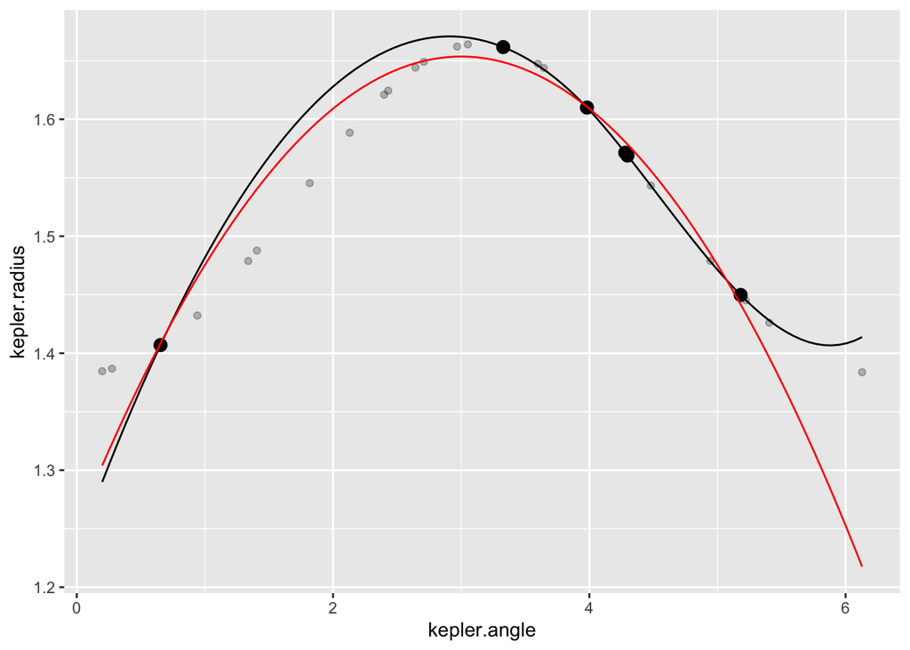

```r
Observations <- kepler_sample(seed=NULL)
connector <- spliner(kepler.radius ~ kepler.angle,
                     data = Observations)
polynomial <- makeFun(lm(kepler.radius ~ poly(kepler.angle, 2),
                         data = Observations))
gf_point(kepler.radius ~ kepler.angle,
         data = Kepler, alpha=0.25) %>%
gf_point(kepler.radius ~ kepler.angle,
         data = Observations, size=3) %>%
  slice_plot(connector(kepler.angle) ~ kepler.angle) %>%
  slice_plot(polynomial(kepler.angle) ~ kepler.angle, color="red")
```

**Code-reading questions**

**Question tmp-1**: The data are stored in an object named `Kepler`. What kind of object is `Kepler`?

1. A data frame (+) []
2. A matrix []
3. A vector []
4. A function []

**Question tmp-2**: There are two variables from Kepler’s data used in the code. What are their names?

1. `time` and `angle` []
2. `distance` and `angle` []
3. `kepler.radius` and `kepler.angle` (+) []
4. `kepler.distance` and `kepler.angle` []

**Question tmp-3**: The object `connector` is defined on lines 2 and 3 of the sandbox code. What kind of R object is `connector`? (Hint, you may need to read further along in the code to figure this out.)

1. A data frame []
2. A number []
3. A vector []
4. A function (+) []

**Question tmp-4**: What kind of R object is `kepler.radius ~ kepler.angle`?

1. A tilde expression (+) []
2. An arithmetic expression []
3. A function []
4. A character string [Character strings always involve quotation marks.]

**Question tmp-5**: The R function `gf_point()` as used here has how many arguments?

1. 1 []
2. 2 []
3. 3 (+) []
4. 4 []

**Question tmp-6**: What’s the give away that `polynomial` (as used here) is a **function**?

1. The name `polynomial` is followed by open and close parentheses. (+) []
2. The name `polynomial` begins with a `p`. []
3. The name `polynomial` is an English verb. [This is a nice programming style to use natural-language verbs to name functions, but it is not at all required by the language. (And “polynomial” isn’t a verb anyway.)]

**Question tmp-7**: Why are there quotation marks in `'red'`?

1. Because the color is only sort of red-ish, not pure red. []
2. Because Mars is the “Red Planet” []
3. Because the word is a literal set of characters, not the name of a function or other R object. (+) []

The black curve in the graphic drawn by the sandbox is a “cubic spline” interpolating function. Remember that the spline was constructed **without reference** to any but the selected points drawn as large dots.

**Question tmp-8**: Does the spline go through the selected points?

1. Yes, right through the middle of the dot. (+) []
2. Pretty close, but tangent to the edge of the dots. []
3. Exactly through some, but not others. []
4. Exactly through the ones in the middle of the domain, but not so well through the ones at the extremes. []

The red curve in the graphic is a “global” polynomial. Here, “global” means “the same polynomial at all points in the domain.”

**Question tmp-9**: Two judge from the shape of the polynomial, what is the order of the polynomial? (Make sure the sandbox is reset to the original code before you form your answer.)

1. Fries and a chocolate shake [Just kidding.]
2. 0 []
3. 1 []
4. 2 (+) [Right, it’s a downward facing parabola.]
5. 3 []
6. 4 []
7. 5 []
8. 6 []

**Question tmp-10**: Does the global polynomial go through the selected points?

1. Yes, through all of them. []
2. It runs tangent to the dots. []
3. It misses almost all of them. (+) [The polynomial needn’t run through any of the data points. That it goes through one here is just a coincidence.]

The 2nd-order polynomial is **not** a function that interpolates these data. This is simply because the six selected data points do not lie on a parabola.

**Question tmp-11**: The six selected points used to construct the spline and the parabola were selected at random. Pick a different six points to to see whether the spline method always constructs an interpolating function and whether the 2nd-order polynomial ever gives an interpolating function for these data. (You can change the random selection by modifying the “seed” used to generate the random sample. To do this, change the first line to give `kepler_sample(seed = NULL)` an argument.) Repeatedly draw the graphic to get some idea of the amount of random variation.

Which of these is true as you look at different samples of data?

1. The cubic spline *always* goes through all the data points but the global, 2nd-order polynomial *hardly ever* goes exactly through all of them. (+) []
2. The cubic spline *often but not always* goes exactly through all the data points but the global, 2nd-order polynomial *sometimes but not often* goes through all of them. []

Change the order of the polynomial used by changing the integer argument in `poly(kepler.angle, 2)`. If you make the integer too large, you’ll get an error message. If you make the integer too small, the global polynomial won’t go exactly through the data.

**Question tmp-12**: What order of polynomial *always* goes exactly through the six selected points.

1. 3 []
2. 4 []
3. 5 (+) []
4. 6 []
5. 7 []

Let’s try making functions based on more data. To do this, in the `kepler_sample()` function use an argument `n`. For instance, `n=10` will select ten instead of the default six points. You can leave the `seed=NULL` argument.

**Question tmp-13**: What order of polynomial *always* goes exactly through 10 randomly selected points. Try several different random samples of data.

1. 6 []
2. 7 []
3. 8 []
4. 9 (+) []
5. 10 []

The global polynomial is a linear combination of power-law functions, e.g.
$$p(x) = a_0 + a_1 x + a_2 x^2 + \cdots$$

The R function `lm()`, which we used last semester, finds the particular coefficients $a_0, a_1, \ldots$ to best match the polynomial to the data. But we could do the same thing by using any other functions we like, e.g. $\sqrt{x}$, $e^x$, $\sin(x/1.2)$, and so on.

A consequence of this is that we always have an infinite number of different interpolating functions. Which one to choose? In the next sections we’ll explore the properties which so often make the cubic spline the preferred method.

Another question is whether we should use any interpolating function in the first place. Perhaps “getting close” to the data is good enough? This is the difference between *interpolating* data and *smoothing* data. The answer to the question, “interpolate or smooth,” depends on the modeling context for which the function is being constructed. Smoothing is based on statistical ideas that we don’t have time to cover in this course, but a core skill of expert modelers is to know when to use interpolation and when to use smoothing.

**Background** (Optional): The raw measurements (not included here) that Kepler used in his calculation were made by Tycho Brahe (1546-1601). Those raw measurements were of the angle of Mars with respect to Earth. Kepler estimated the orbital period of Mars to be 687 Earth days. (The current accepted value is 686.980 days.) Knowing the period, Kepler could find pairs of Earth days separated by multiples of the period. In each pair, the Earth would be in a different position, but Mars would be in the same position. Thus the distance of Mars from Earth could be estimated by triangulation.

The angle was not directly measured for each occasion. Instead, knowing the radius versus time Kepler was able to discern when Mars was at its greatest and closest distance to the Sun. The angle tells where Mars is along its orbit. An angle of 0 is the position when Mars is closest to the Sun. An angle of 3.14 is when Mars is farthest from the Sun.

The `time` is time of the observation given as an interval in Earth days from 8:15am Greenwich time on 9 March 1584.